# Bay Wheel's trip data exploration

## Preliminary Wrangling

This document explores a dataset containing bike trip information of trips made during 2017 via the Bay Wheels public bicycle sharing system in the San Francisco Bay Area. The data has been collected from the Ford GoBike System Data.

### What is the structure of your dataset?

> There are 453,159 records in the dataset. Each record is a bicycle trip made with 15 features (trip duration, starting and ending stations, member gender and so on). There is a mixture of categorical nominal features (station names, gender etc) and quantitative features (birth year, trip duration etc).

### What is/are the main feature(s) of interest in your dataset?

> I am envisioning myself as a business analyst for this bikeshare company and I am in a quest to help the company increase its sales via targeted advertisement. Consequently, I am interested in features that would help the company in answering questions like:
> - Which are the months which show the highest trips?
> - Which are the days which show the highest trips?
> - During which time of the day do people like to avail the bikeshare system?
> - Which starting and ending stations do commuters frequent most?
> - Which of the bikes in the system are most frequently used?
> - Is there any correlation between number of trips and user membership type?
> - How does member gender affect trip frequency?

> All these features, in some way or the other could be expected to affect the number of trips made and hence could be used to gain valuable insights into usage patterns of bike sharing systems that could help companies tailor their services to increase revenue and provide better customer services.

### What features in the dataset do you think will help support your investigation into your feature(s) of interest?

> I expect there to be strong correlations between trip duration / trip frequency and day/hour of the week/day. I expect people to go out and explore more on the weekdays on bikes. Conversely, on weekends also we could find many using the bike system to commute to places to visit. I also expect features like customer type to affect overall trip frequency. It could be well possible that subscribers who are continually committed to the bike sharing service will make more trips as compared to one off customers.

## Univariate Exploration

### Q1. Let us first look at a univariate distribution of the trip duration in minutes and try to find out what is the most common trip duration.

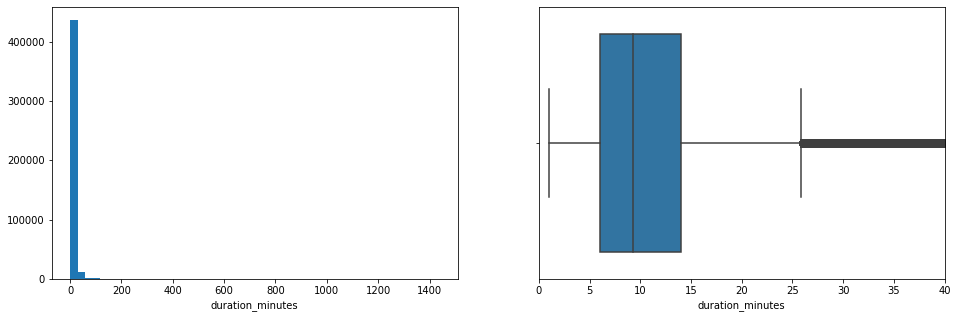

```python
# lets first plot a cursory histogram for the distribution of the trip duration and also a boxplot to show the position of
# the median within the distribution

f, ax = plt.subplots(1, 2, figsize=(16,5)) # type: _,axes.Axes
sns.distplot((data['duration_sec']/60), kde=False, hist_kws={'alpha': 1}, ax=ax[0])
ax[0].set_xlabel('duration_minutes');

sns.boxplot(y=(data['duration_sec']/60), ax=ax[1], orient='h')
ax[1].set_xlabel('duration_minutes');
ax[1].set_xlim(0, 40);
```

From the histogram plot on the left, it is evident that the distribution is highly right skewed and a majority of the trip duration is much less than 100 minutes with some spanning across larger values. Let us look at a box-plot of the trip durations in minutes (on the right) to see if the large values are infact outliers. From a zoomed in version of the boxplot, it shows that most of the larger values of trip durations fall out as outliers. Consequently, we will perform a scaling transformation to the x axis so that we can also bring those points into consideration.

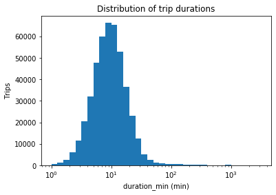

```python
# lets plot the distribution for the trip duration on a log transformed scale

bins = 10**np.arange(0, 3.6, 0.1)
sns.distplot(bins=bins, a=duration_min, kde=False, hist_kws={'alpha':1})
plt.xscale('log')
plt.xlabel('duration_min (min)')
plt.ylabel('Trips')
plt.title('Distribution of trip durations');
```

#### 1. From the distribution of the trip durations, it is evident that most of the trips are around 10 minutes. This is in exact concordance to the boxplot we saw earlier. It would thus be advisable for the company to bolster advertising for those people who make trips around the most frequent duration of 10 minutes. May be the company can expand its network by appealing to more people who frequent the starting and ending stations whose distances fall within that average 10 minutes of trip duration.

### Q2. Now, lets look at how trip frquencies vary across different months.

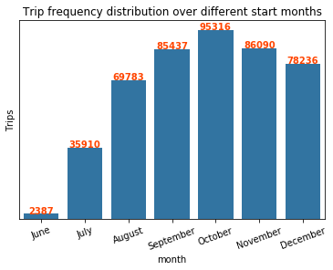

```python
# now plot a barchart to show trip freeuncy over different start months

order = ['June', 'July', 'August', 'September', 'October', 'November', 'December']
color = sns.color_palette()[0]
sns.barplot(x=trip_per_month.index, y=trip_per_month.values, color=color, order=order)
plt.xticks(rotation=20);
locs, labels = plt.xticks()
plt.title('Trip frequency distribution over different start months')
plt.ylabel('Trips')
plt.xlabel('month')
plt.gca().set_yticks([])

for loc, label in zip(locs, labels):
    # get the text property for the label to get the correct count
    count = trip_per_month[label.get_text()]
    # print the annotation just below the top of the bar
    plt.text(loc, count+300, str(count), ha = 'center', color = '#FF4500', fontdict={'weight': 'bold'})
```

#### 2. From the barchart, it is evident that October and surrounding months show the highest frequency of bike share trips with the lowest occurances during the months of June (or July). Probably during the summer months the number of people using bike sharing platforms dwindles. It will thus be advisable for the company to target customers on or near the month of October for the second half of the year.

### Q3. Now, lets look at how trip frquencies vary across different weekdays.

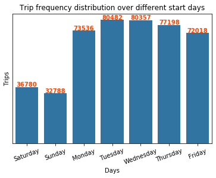

```python
# now plot a barchart to show trip frequency over different start days
day_order = ['Saturday', 'Sunday', 'Monday', 'Tuesday', 'Wednesday', 'Thursday', 'Friday']
color = sns.color_palette()[0]
sns.barplot(x=trip_per_days.index, y=trip_per_days.values, color=color, order=day_order)
plt.xticks(rotation=20);
locs, labels = plt.xticks()
plt.title('Trip frequency distribution over different start days')
plt.ylabel('Trips')
plt.xlabel('Days')
plt.gca().set_yticks([])

for loc, label in zip(locs, labels):
    # get the text property for the label to get the correct count
    count = trip_per_days[label.get_text()]
    # print the annotation just below the top of the bar
    plt.text(loc, count+300, str(count), ha = 'center', color = '#FF4500', fontdict={'weight': 'bold'})
```

#### 3. Perhaps it is not that surprising that the number of trips made on weekdays far outnumbers those made on weekends. Weekday trips are almost more than double of those made on weekends on average.

### Q4. Now, lets look at how trip frquencies vary across different hours on a day.

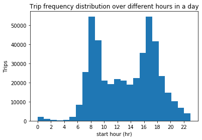

```python
# now plot a histogram to show trip frequency over different start hours
color = sns.color_palette()[0]
sns.distplot(a=data2.start_hour, kde=False, color=color, hist_kws={'alpha': 1}, bins=24)
plt.title('Trip frequency distribution over different hours in a day')
plt.xlabel('start hour (hr)')
plt.ylabel('Trips')
plt.xticks(np.arange(0,24,2));
```

#### 4.The distribution of trip frequency over different hours in a day is bimodal. Perhaps this is not surprising, since we expect that most of the commutes on bikes would happen when people are trying to go to work in the morning (peak at 8 hrs), and then subsequently returning home during the evening (peak at 17 hrs). The trip frequency remains at an average of around 20,000 trips between those two peaks while they decline fast on either ends. It is interesting to see that there are commuters using bikes as early as 2am or 3am in the morning.

### Q5. Now, lets look at how trip frquencies vary across different user types.

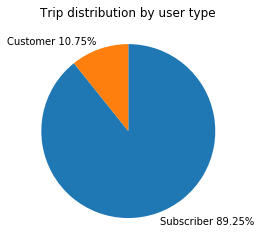

```python
# plot a pie chart depicting the percentage type of users of the bike share system
trip_per_user_type = data2.user_type.value_counts()
total = sum(trip_per_user_type.values)
labels = [f"Subscriber {(100*trip_per_user_type['Subscriber']/total):0.2f}%",
          f"Customer {(100*trip_per_user_type['Customer']/total):0.2f}%"]
plt.title('Trip distribution by user type')
plt.pie(trip_per_user_type, labels=labels, startangle=90, counterclock=False);
```

#### 5. Almost 90% of the bike riders are subscribers while a meagre 10% are customers who do one off purchases. It would thus be advisable for the company to concentrate and provide better service to its loyal subscribers who create the bulk of its business.

### Q6. Now, lets look at how trip frquencies vary across different user ages.

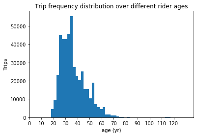

```python
# now plot a histogram to show trip frequency over different rider ages
color = sns.color_palette()[0]
sns.distplot(a=data2.rider_age, kde=False, color=color, hist_kws={'alpha': 1})
plt.title('Trip frequency distribution over different rider ages')
plt.xlabel('age (yr)')
plt.ylabel('Trips')
plt.xticks(np.arange(0,130,10));
```

#### 6.The distribution of trip frequency over different rider ages is unimodal, with a peak at around the age of 35 years and is right skewed. Perhaps, a majority of these riders are office commuting individuals who avail long term bike sharing plans via subscription, like we observed previously. It would thus be advisable for the company to target its services towards the 20-40 years old age and profession group which has the potential of bringing it the largest amount of revenue. It is interesting to see that there have been riders above the age of 110!

### Q7. Now, lets look at how trip frquencies vary across different rider genders.

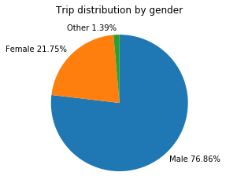

```python
# plot a pie chart depicting the percentage type of genders of the bike share system
trip_per_user_gender = data2.member_gender.value_counts()
total = sum(trip_per_user_gender.values)
labels = [f"Male {(100*trip_per_user_gender['Male']/total):0.2f}%",
          f"Female {(100*trip_per_user_gender['Female']/total):0.2f}%",
         f"Other {(100*trip_per_user_gender['Other']/total):0.2f}%"]
plt.title('Trip distribution by gender')
plt.pie(trip_per_user_gender, labels=labels, startangle=90, counterclock=False);
```

#### 7. Males use the bike sharing service almost overwhelmingly over females and other genders identities. It will be perhaps advisable for the company to device services and plans that would encourage females and other gender identitites to avail the bike sharing system even more, possibly having potentials of opening avenues of whole new market sectors.

### Q8. What are the top 10 most popular starting stations for riders?

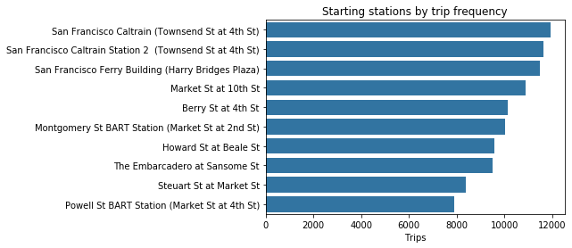

```python
sorted_by_start_station = data2.start_station_name.value_counts()[:10]
plt.title('Starting stations by trip frequency')
plt.xlabel('Trips')
sns.barplot(y=sorted_by_start_station.index, x=sorted_by_start_station.values, color=color);
```

The most popular starting station is San Franciso Caltrain.

### Q9. What are the top 10 most popular ending stations for riders?

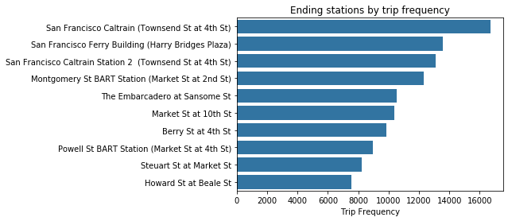

```python
sorted_by_end_station = data2.end_station_name.value_counts()[:10]
plt.title('Ending stations by trip frequency')
plt.xlabel('Trip Frequency')
sns.barplot(y=sorted_by_end_station.index, x=sorted_by_end_station.values, color=color);
```

#### 8/9. The most popular destination is also San Franciso Caltrain.The company can target these popular starting and ending stations by making their services more convenient and improving customer experience such that the high volume of trips along these routes are mantained.

### Q10. What are the top 10 most popular start/end station combinations?

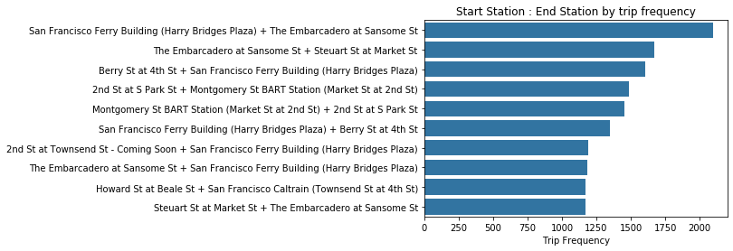

```python
sorted_by_station_combined = (data2['start_station_name'] + " + " + data2['end_station_name']).value_counts()[:10]
plt.title('Start Station : End Station by trip frequency')
plt.xlabel('Trip Frequency')
sns.barplot(y=sorted_by_station_combined.index, x=sorted_by_station_combined.values, color=color);
```

### Discuss the distribution(s) of your variable(s) of interest. Were there any unusual points? Did you need to perform any transformations?

- The distribution of trip duration was highly right skewed. Therefore, I looked at the distribution using a log transform and found out that the median trip duration is around 10 minutes.

### Of the features you investigated, were there any unusual distributions? Did you perform any operations on the data to tidy, adjust, or change the form of the data? If so, why did you do this?

- It was interesting to see that most of the trips occur on the month of October. It requires further investigation to see if bike sharing usage patterns are correlated to outside weather. This might help the company to plan for and make adjustments for different seasons.
- The distribution of trip frequencies over rider ages showed that there are outliers in the age range of 90-120. These outliers, however, were not removed since they are low in number and it cannot be positively said that these come from erroneous data records since there has been past instances of people living in that age range.

## Bivariate Exploration

### Q11. There seems to be a slight negative correlation coefficient between the duration_min and rider_age. Is it true?

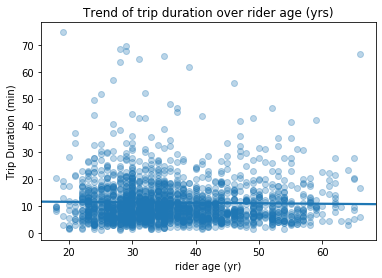

```python
# lets plot a scatterplot of duration_min Vs rider_age
sns.regplot(data=data3_sampl, x='rider_age', y='duration_min', y_jitter=0.3, scatter_kws={'alpha': 0.3}, ci=None)
plt.xlabel('rider age (yr)')
plt.ylabel('Trip Duration (min)')
plt.title('Trend of trip duration over rider age (yrs)');
```

#### 11 (i). Yes, it is infact evident from the scatterplot above that as the rider age increases, the trip duration decreases slightly. The reason behind a negative coefficient could be that older riders dont go too far from their starting points, or may be bikes are more chosen by younger, more athletic subscribers. This trend shows that, although there is a negative correlation between the trip duration and rider age, the strength is pretty weak and close to zero and the company should not make any marketing decisions just based on the age of the riders.

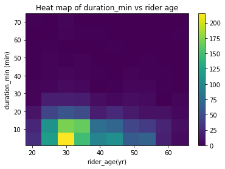

```python
plt.hist2d(data=data3_sampl, y='duration_min', x='rider_age')
plt.colorbar()
plt.title('Heat map of duration_min vs rider age')
plt.ylabel('duration_min (min)')
plt.xlabel('rider_age(yr)');
```

#### 11(ii).The heatmap of the trip duration and rider age shows that most riders are around 30 years old and make less than or equal to 10 mintutes trips. This is an important information for the company as it depicts what age group and what average trip duration to target while planning for newer services.

### Q12. There seems to be a slight positive correlation coefficient between the duration_min and start_hour. Is it true?

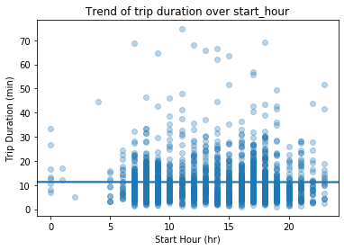

```python
# lets plot a scatterplot of duration_min Vs start_hour
sns.regplot(data=data3_sampl, y='duration_min', x='start_hour', scatter_kws={'alpha': 0.3}, ci=None)
plt.xlabel('Start Hour (hr)')
plt.ylabel('Trip Duration (min)')
plt.title('Trend of trip duration over start_hour');
```

#### 12(i). Yes, it is infact evident from the scatterplot above that as the start hour increases, the trip duration increases very slightly. The reason behind a positive coefficient could be that trips later in the day as opposed to in the very early hours are usually towards destinations to and from office or schools which are generally longer distances and longer trip durations. However, like before, due to the weak association between duration_min and start_hour, they should not be used in marketing decisions.

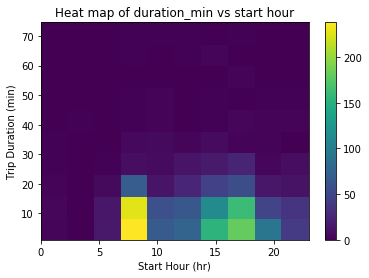

```python
plt.hist2d(data=data3_sampl, y='duration_min', x='start_hour')
plt.colorbar()
plt.title('Heat map of duration_min vs start hour')
plt.ylabel('Trip Duration (min)')
plt.xlabel('Start Hour (hr)');
```

#### 12(ii). The heatmap above shows that most trips start in office going and office leaving times are are of mostly around 5 - 20 minutes trips in general. Again, this gives important information to the company as to which trip duration services and which start hours of the day they should taylor their services to.

### Q13. How do trip durations vary across months?

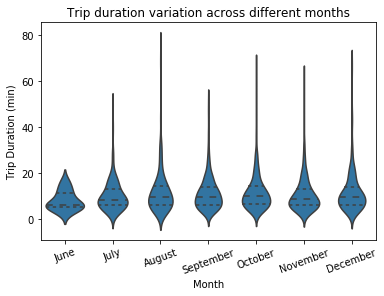

```python
color = sns.color_palette()[0]
order = ['June', 'July', 'August', 'September', 'October', 'November', 'December']
sns.violinplot(data=data3_sampl, x='start_month', y='duration_min', color=color, order=order, inner='quartile')
plt.title('Trip duration variation across different months')
plt.ylabel('Trip Duration (min)')
plt.xlabel('Month')
plt.xticks(rotation=20);
```

### Q14. How do trip durations vary across user types?

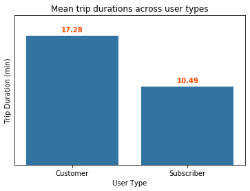

```python
groupby_user = data3_sampl.groupby(by='user_type', as_index=False).mean()
sns.barplot(data=groupby_user, x='user_type', y='duration_min', color=color)
plt.title('Mean trip durations across user types');
locs, labels = plt.xticks()
plt.ylabel('Trip Duration (min)')
plt.xlabel('User Type')
plt.gca().set_yticks([])
plt.ylim(0, 20)
for loc, label in zip(locs, labels):
    # get the text property for the label to get the correct count
    count = groupby_user[groupby_user['user_type'] == label.get_text()]['duration_min'].values[0]
    count = float(f"{count:0.2f}")
    # print the annotation just below the top of the bar
    plt.text(loc, count+0.5, str(count), ha = 'center', color = '#FF4500', fontdict={'weight': 'bold'})
```

#### 14. This is a very interesting finding. Customers on average spend more time in trips as compared to subscribers althought around 90% of the users are actually subscribers. This can be explained because subscribers are regular commuters whereas customers make one off purchases possibly for long distance journeys.

### Q15. How do trip durations vary across different start days?

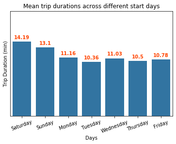

```python
groupby_day = data3_sampl.groupby(by='start_day', as_index=False).mean()
sns.barplot(data=groupby_day, x='start_day', y='duration_min', color=color, order=day_order)
plt.xticks(rotation=20)
plt.ylabel('Trip Duration (min)')
plt.xlabel('Days')
plt.title('Mean trip durations across different start days');

locs, labels = plt.xticks()
plt.gca().set_yticks([])
plt.ylim(0, 20)
for loc, label in zip(locs, labels):
    # get the text property for the label to get the correct count
    count = groupby_day[groupby_day['start_day'] == label.get_text()]['duration_min'].values[0]
    count = float(f"{count:0.2f}")
    # print the annotation just below the top of the bar
    plt.text(loc, count+0.5, str(count), ha = 'center', color = '#FF4500', fontdict={'weight': 'bold'})
```

#### 15. This is another suprising and interesting find. Although the trip numbers on weekdays outnumber those on weekends like we found in univariate exploration, but the mean trip durations on weekends are larger than those on weekdays. So, people make fewer but much longer trips on weekends. The company thus can cater services to users on weekends that allow them to go for longer rides without having to may too much. This can potentially increase the number of customers.

### Q16. How do trip durations vary across different genders?

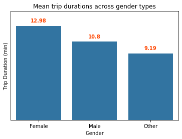

```python
groupby_gender = data3_sampl.groupby(by='member_gender', as_index=False).mean()
sns.barplot(data=groupby_gender, x='member_gender', y='duration_min', color=color)
plt.ylabel("Trip Duration (min)")
plt.xlabel("Gender")
plt.title('Mean trip durations across gender types');

locs, labels = plt.xticks()
plt.gca().set_yticks([])
plt.ylim(0, 15)
for loc, label in zip(locs, labels):
    # get the text property for the label to get the correct count
    count = groupby_gender[groupby_gender['member_gender'] == label.get_text()]['duration_min'].values[0]
    count = float(f"{count:0.2f}")
    # print the annotation just below the top of the bar
    plt.text(loc, count+0.5, str(count), ha = 'center', color = '#FF4500', fontdict={'weight': 'bold'})
```

### Q17. How are user type usage patterns spread out across different days?

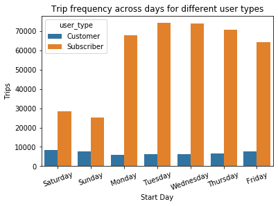

```python
sns.countplot(data=data3, x='start_day', hue='user_type', order=day_order)
plt.title('Trip frequency across days for different user types')
plt.ylabel('Trips')
plt.xlabel('Start Day')
plt.xticks(rotation=20);
```

## Multivariate Exploration

### Q18. Are there any difference in the trip frequency patterns over weekdays, for different months?

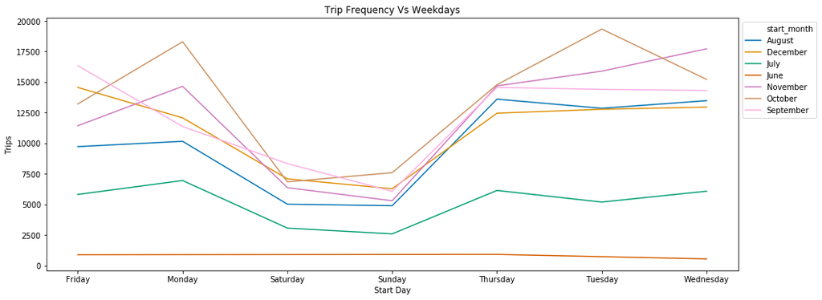

```python
f, ax = plt.subplots(1,1, figsize=(16,6))
a = data3.groupby(['start_month', 'start_day'], as_index=False).count()
sns.lineplot(data=a, x='start_day', y='duration_min', hue='start_month', ax=ax, palette='colorblind')
plt.title('Trip Frequency Vs Weekdays')
plt.legend(loc='upper left', bbox_to_anchor=(1, 1), ncol=1)
plt.ylabel('Trips')
plt.xlabel('Start Day');
```

#### 18. Almost all of the months show similar patterns of trip frequencies over the week days, with significant dips in trip numbers on weekend days. October shows the highest overall trips, with June the lowest. Marketing strategy should be targeted in increasing revenue in the lull summer months like June or July and in the weekends.

### Q19. We have see trip duration patterns over different user types. how does gender come into the play?

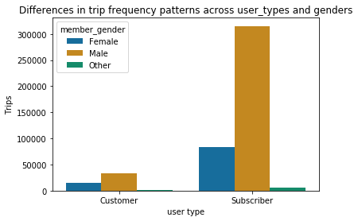

```python
bb = data3.groupby(by=['user_type', 'member_gender'], as_index=False).count()
sns.barplot(data=bb, x='user_type', y='duration_min', color=color, hue='member_gender', palette="colorblind")
plt.ylabel('Trips')
plt.xlabel('user type')
plt.title('Differences in trip frequency patterns across user_types and genders');
```

### Q20. How does trip duration change across the same user types and genders

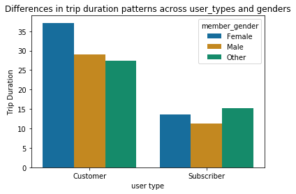

```python
cc = data3.groupby(by=['user_type', 'member_gender'], as_index=False).mean()
sns.barplot(data=cc, x='user_type', y='duration_min', color=color, hue='member_gender', palette="colorblind")
plt.ylabel('Trip Duration')
plt.xlabel('user type')
plt.title('Differences in trip duration patterns across user_types and genders');
```

### Q21. If there is an age group that the marketing team of the bike sharing company should target, what is that age group?

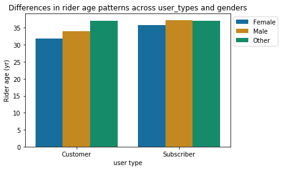

```python
dd = data3.groupby(by=['user_type', 'member_gender'], as_index=False).mean()
sns.barplot(data=dd, x='user_type', y='rider_age', color=color, hue='member_gender', palette="colorblind");
plt.legend(loc='upper left', bbox_to_anchor=(1, 1), ncol=1)
plt.ylabel('Rider age (yr)')
plt.xlabel('user type')
plt.title('Differences in rider age patterns across user_types and genders');
```

#### 21. From the barchart above, it can be seen that the mean age group across all user types and genders fall above the 30 yrs line and is below the 40 yrs line. It is this group that the company should aim at.